# General Regression: Ridge, Lasso, PCR & PLS

Pouria

4/18/2022

# Prompt

Looking at the `College` data set, we intend to predict the number of applications received, `Apps`, using the other variables.

1. Split the data set into a training set and a test set with 20% of the data held out as the test set.
2. Fit a PCR model on the training set, with M chosen by cross-validation. Report the test error obtained, along with the value of M selected by cross-validation.
3. Fit a PLS model on the training set, with M chosen by cross-validation. Report the test error obtained, along with the value of M selected by cross-validation.
4. Fit a linear model using least squares on the training set, and report the test error obtained.
5. Fit a ridge regression model on the training set, with $\lambda$ chosen by cross-validation. Report the test error obtained.
6. Fit a lasso model on the training set, with λ chosen by cross-validation. Report the test error obtained, along with the number of non-zero coefficient estimates.
7. Comment on the results obtained. How accurately can we predict the number of college applications received? Calculate test R-squared values. Is there much difference among the test errors resulting from these five approaches?

# Libraries

```r
library(ISLR)
library(glmnet)
library(pls)
library(ggplot2)
library(GGally)
library(dplyr)
library(tidyr)
```

# Set seed

```r
set.seed(11)
```

# (a) Split the data

Split the data set into a training set and a test set. Hold 20% of the data out for test.

```r
sum(is.na(College))
```

```
## [1] 0
```

```r
# College[, "Apps"] = College[, "Apps"] + rnorm(dim(College)[1], 1000, 4500)

College[, "Apps"] = College[, "Apps"] + rnorm(dim(College)[1], 1000, 10000)


# College1 <- data.frame(College,
#                        var1 = rnorm(dim(College)[1], 1000,5000),
#                        var2 = rnorm(dim(College)[1], 2000, 1000))

train.size = round(dim(College)[1] *.8)
train = sample(dim(College)[1], train.size)
test = -train

College.train <- College[train, ]
College.test  <- College[test, ]

dim(College.train)
```

```
## [1] 622  18
```

```r
train.size
```

```
## [1] 622
```

```r
var(College[, "Apps"])
```

```
## [1] 113663005
```

# (b) Principal Component Regression (PCR)

- Fit a PCR model on the training set, with number of PCs chosen by cross-validation. Visualize the results.
- Report the test error corresponding with the number of PCs selected from above.
- Report the variance explained in both predictors and response spaces across different number of PCs.

# (b) PCR

1. Perform PCR on the training set and visualize MSE across number of PCs using cross-validation.

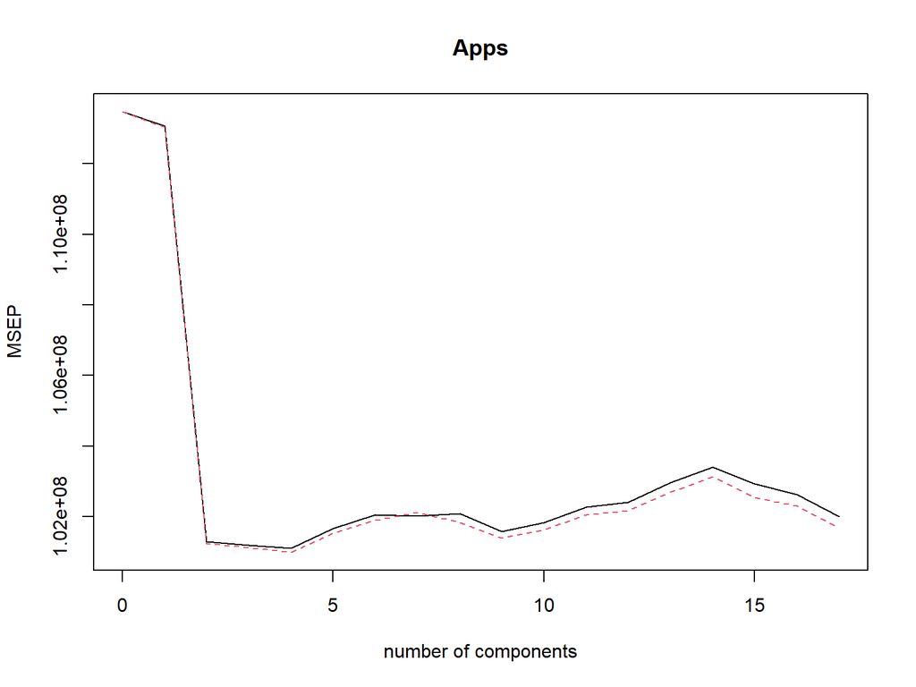

```r
pcr.cv = pcr(Apps~., data=College.train, scale=T, validation="CV")

validationplot(pcr.cv, val.type="MSEP")
```

# (b) PCR

- Can you manually plot what `validationplot()` gave you above?

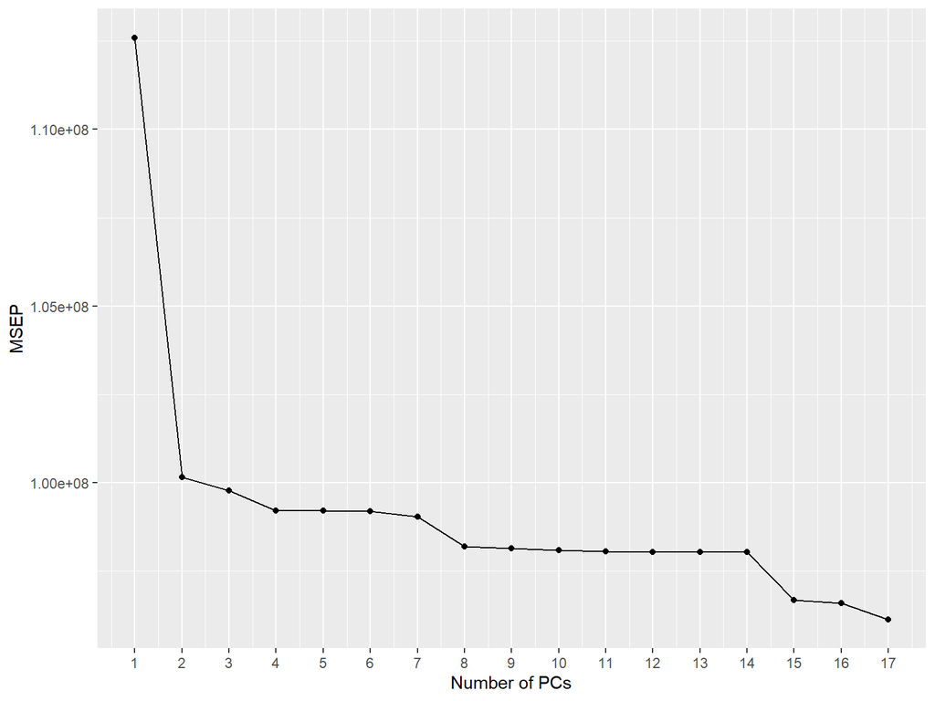

```r
res.pcr <- apply(pcr.cv$residuals[,1,], 2, function(x) mean(x^2))

ggplot() +
  geom_line(aes(1:pcr.cv$ncomp, res.pcr)) +
  geom_point(aes(1:pcr.cv$ncomp, res.pcr)) +
  xlab("Number of PCs") +
  ylab("MSEP") +
  scale_x_continuous(breaks = seq(1,pcr.cv$ncomp, 1))
```

# (b) PCR

Use `selectNcomp()` to select the number of PCs that correspond to 1 SE.

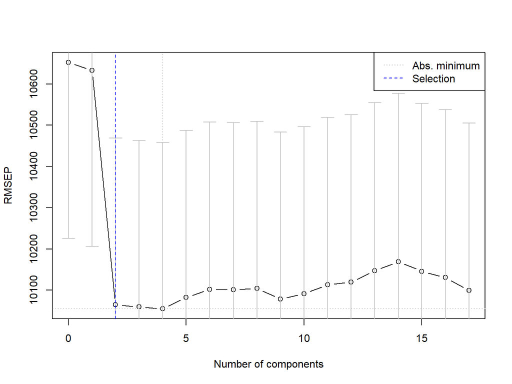

```r
N.PC <- selectNcomp(pcr.cv, method = "onesigma", plot = TRUE)
```

# (b) PCR

2. Report the test MSE for PCR with the number of PCs selected above.

```r
pcr.pred = predict(pcr.cv, College.test, ncomp=N.PC)

pcr.mse <- mean((College.test[, "Apps"] - pcr.pred)^2)

pcr.mse
```

```
## [1] 101071519
```

# (b) PCR

3. Report a summary of the PCR model and visualize the variance explained in predictors space for different number of PCs.
- Summary

```r
summary(pcr.cv)
```

```
## Data:    X dimension: 622 17
##  Y dimension: 622 1
## Fit method: svdpc
## Number of components considered: 17
##
## VALIDATION: RMSEP
## Cross-validated using 10 random segments.
##        (Intercept)  1 comps  2 comps  3 comps  4 comps  5 comps  6 comps
## CV           10653    10633    10065    10059    10055    10083    10102
## adjCV        10653    10632    10062    10056    10049    10076    10095
##        7 comps  8 comps  9 comps  10 comps  11 comps  12 comps  13 comps
## CV       10101    10104    10079     10091     10113     10119     10147
## adjCV    10105    10092    10069     10081     10102     10108     10134
##        14 comps  15 comps  16 comps  17 comps
## CV        10169     10146     10131     10100
## adjCV     10155     10127     10114     10084
##
## TRAINING: % variance explained
##       1 comps  2 comps  3 comps  4 comps  5 comps  6 comps  7 comps  8 comps
## X     31.8440    57.81    64.97    70.62    75.92    80.79    84.26    87.66
## Apps   0.4644    11.46    11.79    12.29    12.30    12.31    12.44    13.18
##       9 comps  10 comps  11 comps  12 comps  13 comps  14 comps  15 comps
## X       90.80     93.09     95.22     96.98     98.00     98.72     99.33
## Apps    13.24     13.28     13.32     13.32     13.32     13.33     14.53
##       16 comps  17 comps
## X        99.81    100.00
## Apps     14.61     15.01
```

# (b) PCR

3. Report a summary of the PCR model and visualize the variance explained in both predictors and response variable spaces for different number of PCs.
- Visualize the variance explained

*Hint 1*: You may access the variance in predictors through `$Xvar`. Remember to use cumulative sum.

*Hint 2*: Also, `$residuals[,1,]` will give you the residuals for each number of PCs. Note that residuals and variance in response variable `Apps` are related. Variance explained in response variable space is the same as $R^2$.

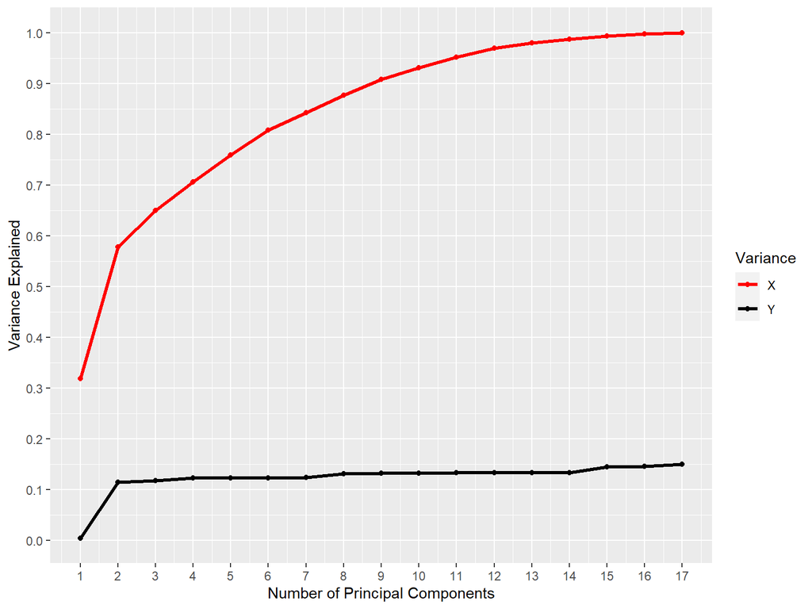

```r
XVar <- cumsum(pcr.cv$Xvar) / pcr.cv$Xtotvar

Yres <- apply(pcr.cv$residuals[,1,], 2, function(x) 1 - mean(x^2)/mean((College.train[,"Apps"]-mean(College.train[,"Apps"]))^2))

pcr.explained.df <- data.frame(N.Comp = 1:pcr.cv$ncomp, X = XVar, Y = Yres) %>%
  pivot_longer(cols = 2:3, names_to = "Variance", values_to = "Var.Values")


ggplot(pcr.explained.df) +
  geom_line(aes(N.Comp,Var.Values, col = Variance), size = 1.1) +
  geom_point(aes(N.Comp,Var.Values, col = Variance)) +
  scale_color_manual(values = c("red", "black")) +
  xlab("Number of Principal Components") +
  ylab("Variance Explained") +
  scale_x_continuous(breaks = seq(1,pcr.cv$ncomp, 1)) +
  scale_y_continuous(breaks = seq(0,1, .1))
```

# (c) Partial Least Square Regression (PLSR)

- Fit a PLS model on the training set, with number of components chosen by cross-validation.
- Report the test error obtained, along with the value of M selected by cross-validation.
- Report the variance explained in both predictors and response spaces across different number of PCs.

# (c) PLSR

1. Perform PLS on the training set and visualize MSE across number of components using cross-validation.

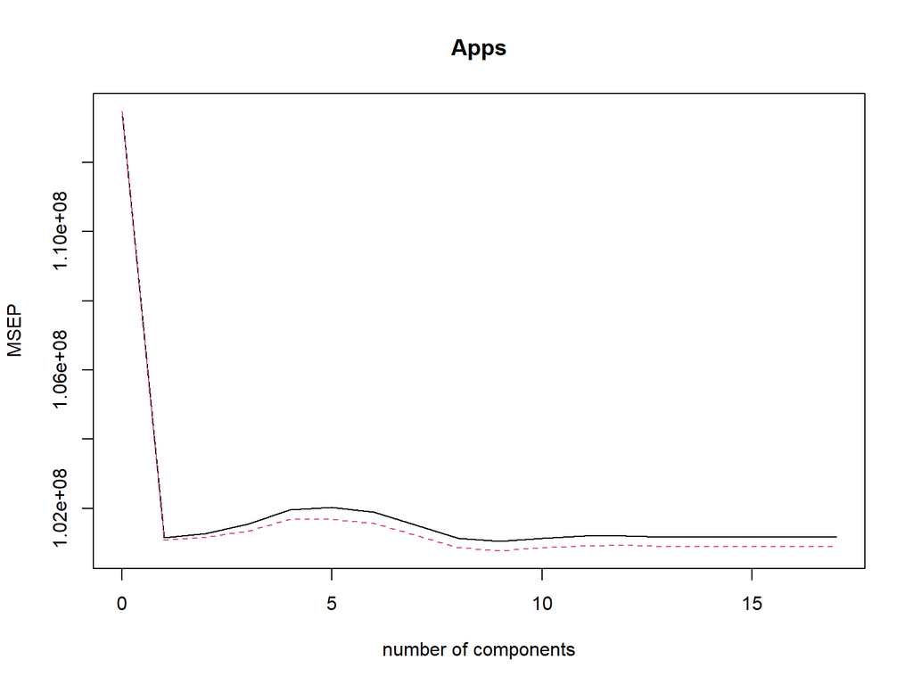

```r
pls.cv = plsr(Apps~., data=College.train, scale=T, validation="CV")
validationplot(pls.cv, val.type="MSEP")
```

# (c) PLSR

- Plot manually

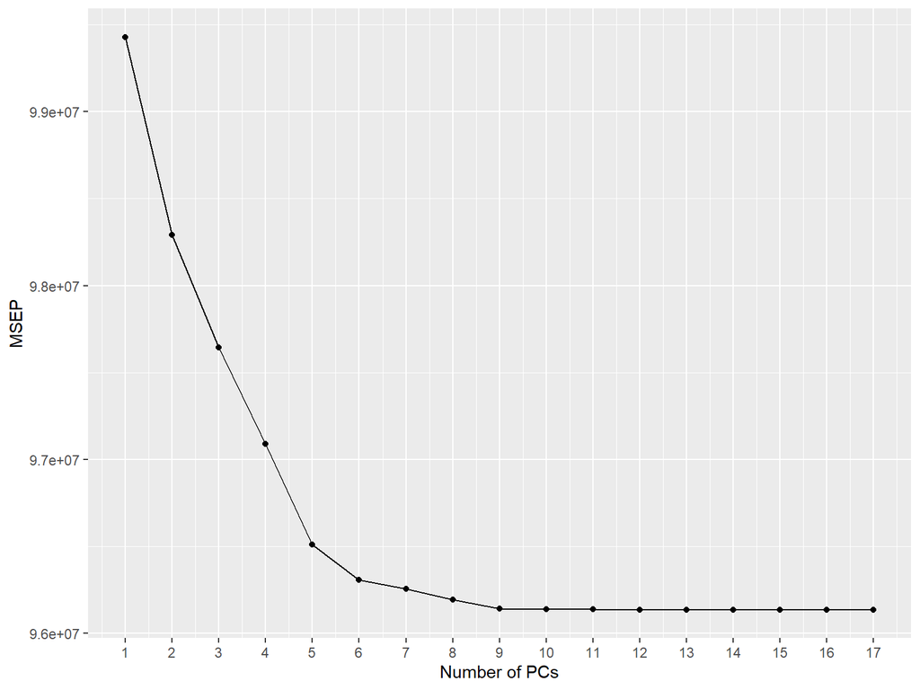

```r
res.pls <- apply(pls.cv$residuals[,1,], 2, function(x) mean(x^2))

ggplot() +
  geom_line(aes(1:pls.cv$ncomp, res.pls)) +
  geom_point(aes(1:pls.cv$ncomp, res.pls)) +
  xlab("Number of PCs") +
  ylab("MSEP") +
  scale_x_continuous(breaks = seq(1,pls.cv$ncomp, 1))
```

# (c) PLSR

Use `selectNcomp()` to select the number of PCs that correspond to 1 SE.

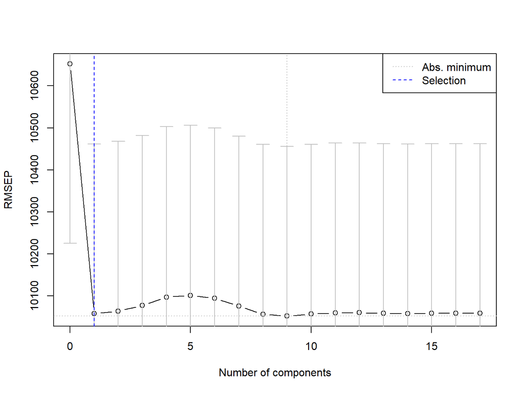

```r
N.PC <- selectNcomp(pls.cv, method = "onesigma", plot = TRUE)
```

# (c) PLSR

2. Report the test MSE for PLS with the number of PCs selected above.

```r
pls.pred = predict(pls.cv, College.test, ncomp=N.PC)
pls.mse <- mean((College.test[, "Apps"] - pls.pred)^2)
pls.mse
```

```
## [1] 100604994
```

# (c) PLSR

3. Report a summary of the PCR model and visualize the variance explained in predictors space for different number of PCs.
- Summarize

```r
summary(pls.cv)
```

```
## Data:    X dimension: 622 17
##  Y dimension: 622 1
## Fit method: kernelpls
## Number of components considered: 17
##
## VALIDATION: RMSEP
## Cross-validated using 10 random segments.
##        (Intercept)  1 comps  2 comps  3 comps  4 comps  5 comps  6 comps
## CV           10653    10058    10064    10077    10097    10101    10095
## adjCV        10653    10054    10058    10067    10084    10084    10078
##        7 comps  8 comps  9 comps  10 comps  11 comps  12 comps  13 comps
## CV       10076    10057    10052     10057     10060     10060     10059
## adjCV    10061    10043    10039     10043     10046     10046     10045
##        14 comps  15 comps  16 comps  17 comps
## CV        10058     10058     10058     10058
## adjCV     10044     10045     10045     10045
##
## TRAINING: % variance explained
##       1 comps  2 comps  3 comps  4 comps  5 comps  6 comps  7 comps  8 comps
## X        26.2    43.24    62.83    67.39    70.48    74.51    76.81    79.56
## Apps     12.1    13.11    13.68    14.17    14.68    14.86    14.91    14.96
##       9 comps  10 comps  11 comps  12 comps  13 comps  14 comps  15 comps
## X       82.03     85.10     88.42     91.22     92.95     94.99     97.22
## Apps    15.00     15.01     15.01     15.01     15.01     15.01     15.01
##       16 comps  17 comps
## X        99.21    100.00
## Apps     15.01     15.01
```

# (c) PLSR

3. Report a summary of the PCR model and visualize the variance explained in both predictors and response variable spaces for different number of PCs.
- Visualize the variance explained

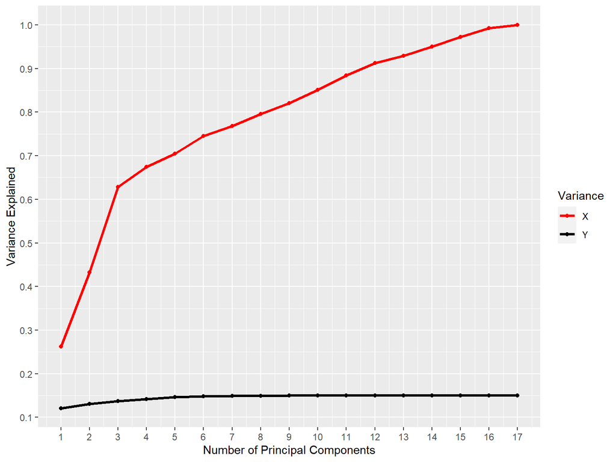

```r
XVar <- cumsum(pls.cv$Xvar) / pls.cv$Xtotvar

Yres <- apply(pls.cv$residuals[,1,], 2, function(x) 1 - mean(x^2)/mean((College.train[,"Apps"]-mean(College.train[,"Apps"]))^2))

pls.explained.df <- data.frame(N.Comp = 1:pls.cv$ncomp, X = XVar, Y = Yres) %>%
  pivot_longer(cols = 2:3, names_to = "Variance", values_to = "Var.Values")


ggplot(pls.explained.df) +
  geom_line(aes(N.Comp,Var.Values, col = Variance), size = 1.1) +
  geom_point(aes(N.Comp,Var.Values, col = Variance)) +
  scale_color_manual(values = c("red", "black")) +
  xlab("Number of Principal Components") +
  ylab("Variance Explained") +
  scale_x_continuous(breaks = seq(1,pls.cv$ncomp, 1)) +
  scale_y_continuous(breaks = seq(0,1, .1))
```

# (b) & (c)

Compare the results from PCR and PLS. How are the values and plots in (c) different from those obtained for PCR in (b). How can this difference be rationalized?

# (d) Fit a linear model

Fit a linear model using least squares on the training set, and report the test error obtained.

```r
lm.fit = lm(Apps~., data=College.train)
summary(lm.fit)
```

```
##
## Call:
## lm(formula = Apps ~ ., data = College.train)
##
## Residuals:
##      Min       1Q   Median       3Q      Max
## -28164.1  -6495.8   -103.8   6786.4  29106.2
##
## Coefficients:
##               Estimate Std. Error t value Pr(>|t|)
## (Intercept) -7.108e+03  4.496e+03  -1.581   0.1144
## PrivateYes  -1.604e+03  1.511e+03  -1.062   0.2887
## Accept       1.799e+00  4.265e-01   4.217 2.85e-05 ***
## Enroll      -3.535e+00  1.920e+00  -1.841   0.0662 .
## Top10perc   -1.609e+01  5.846e+01  -0.275   0.7832
## Top25perc    3.611e+01  4.705e+01   0.767   0.4432
## F.Undergrad  2.738e-01  3.416e-01   0.801   0.4232
## P.Undergrad -1.667e-02  3.464e-01  -0.048   0.9616
## Outstate     2.465e-02  2.025e-01   0.122   0.9032
## Room.Board   5.969e-01  5.214e-01   1.145   0.2527
## Books       -3.756e+00  2.614e+00  -1.437   0.1512
## Personal     7.412e-01  6.825e-01   1.086   0.2778
## PhD          3.197e+01  5.326e+01   0.600   0.5486
## Terminal     1.589e+01  5.833e+01   0.273   0.7853
## S.F.Ratio    1.307e+02  1.398e+02   0.935   0.3503
## perc.alumni -1.969e+01  4.492e+01  -0.438   0.6612
## Expend       8.941e-02  1.297e-01   0.689   0.4910
## Grad.Rate    2.501e+01  3.192e+01   0.784   0.4335
## ---
## Signif. codes:  0 '***' 0.001 '**' 0.01 '*' 0.05 '.' 0.1 ' ' 1
##
## Residual standard error: 9950 on 604 degrees of freedom
## Multiple R-squared:  0.1501, Adjusted R-squared:  0.1262
## F-statistic: 6.275 on 17 and 604 DF,  p-value: 1.134e-13
```

```r
lm.pred = predict(lm.fit, College.test)
ols.mse <- mean((College.test[, "Apps"] - lm.pred)^2)

ols.mse
```

```
## [1] 97360423
```

# (e) Ridge Regression

- Fit a ridge regression model on the training set, with $\lambda$ chosen by cross-validation.
- Report the test error obtained.

# (e) Ridge Regression

1. First, turn the data into matrix to take care of categorical variables; One method to do this is `model.matrix` for both test and train sets. Note that this should be used for `cv.glmnet()`.

```r
train.mat = model.matrix(Apps~., data=College.train)
test.mat = model.matrix(Apps~., data=College.test)
```

# (e) Ridge Regression

2. Now, Find the best $\lambda$.

```r
cv.ridge = cv.glmnet(train.mat, College.train[, "Apps"], alpha=0)
lambda.best = cv.ridge$lambda.min
lambda.best
```

```
## [1] 4125.972
```

# (e) Ridge Regression

3. Now, report the test error using Ridge with best $\lambda$.

```r
ridge.pred <- predict(cv.ridge, newx=test.mat, s=lambda.best)

ridge.mse <- mean((College.test[, "Apps"] - ridge.pred)^2)

ridge.mse
```

```
## [1] 98464810
```

# (f) Lasso Regression

- Fit a lasso model on the training set, with $\lambda$ chosen by cross-validation.
- Report the test error obtained, …
  - along with the coefficients.

# (f) Lasso Regression

1. Now, Find the best $\lambda$.

```r
cv.lasso = cv.glmnet(train.mat, College.train[, "Apps"], alpha=1)
lambda.best = cv.lasso$lambda.1se
lambda.best
```

```
## [1] 2101.827
```

# (f) Lasso Regression

2. Now, report the test error using Lasso with best $\lambda$.

```r
lasso.pred <- predict(cv.lasso, newx=test.mat, s=lambda.best)

lasso.mse <- mean((College.test[, "Apps"] - lasso.pred)^2)

lasso.mse
```

```
## [1] 103821120
```

# (f) Lasso Regression

3. Report the coefficients of the best Lasso model with best $\lambda$.

```r
# lasso.out <- glmnet(model.matrix(Apps~., data=College), College[, "Apps"], alpha=1)
predict(cv.lasso, type="coefficients", s=lambda.best)
```

```
## 19 x 1 sparse Matrix of class "dgCMatrix"
##                        1
## (Intercept) 3180.7157613
## (Intercept)    .
## PrivateYes     .
## Accept         0.6421275
## Enroll         .
## Top10perc      .
## Top25perc      .
## F.Undergrad    .
## P.Undergrad    .
## Outstate       .
## Room.Board     .
## Books          .
## Personal       .
## PhD            .
## Terminal       .
## S.F.Ratio      .
## perc.alumni    .
## Expend         .
## Grad.Rate      .
```

# (g) Compare Models

Comment on the results obtained.

- How accurately can we predict the number of college applications received?
- Is there much difference among the test errors resulting from these five approaches? Visualize using bar-plots.
- Calculate test R-squared values and compare. Visualize using bar-plots.

# (g) Compare Models

1. Is there much difference among the test errors resulting from these five approaches? Visualize using bar-plots.

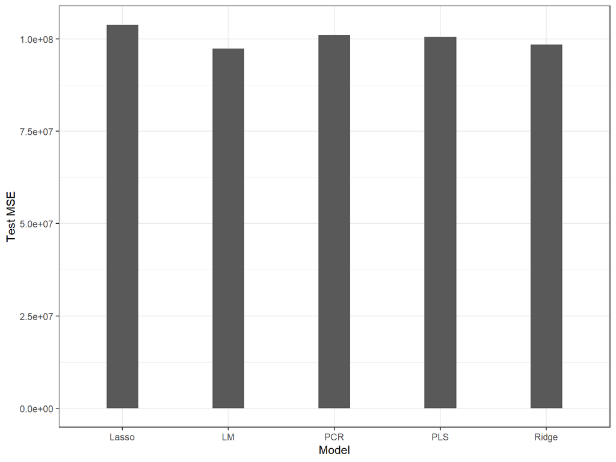

```r
df.mse <- data.frame(Model = c("LM", "Ridge", "Lasso", "PCR", "PLS"),
                     MSE = c(ols.mse, ridge.mse, lasso.mse, pcr.mse, pls.mse))

ggplot(df.mse) +
  geom_col(aes(Model, MSE), width = .3) +
  ylab("Test MSE") +
  theme_bw()
```

# (g) Compare Models

2. Calculate test R-squared values and compare. Visualize using bar-plots.

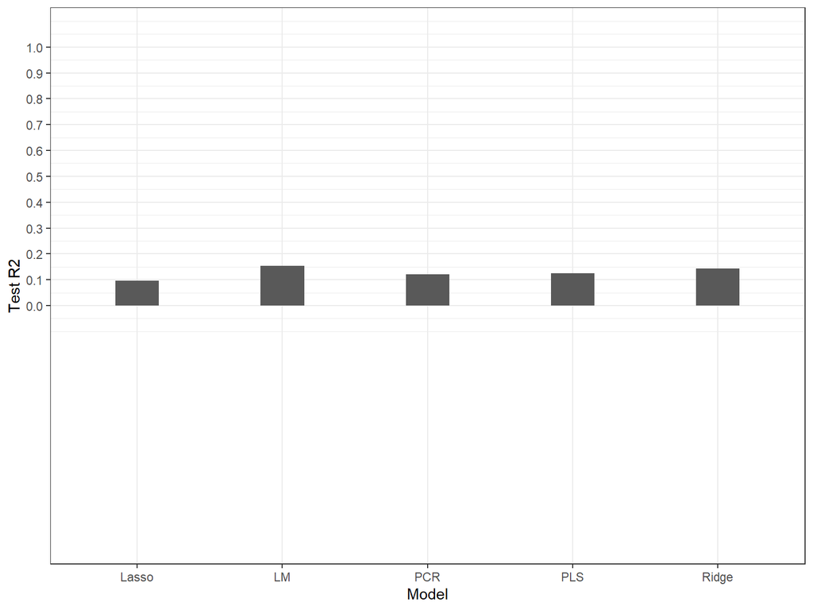

```r
test.avg = mean(College.test[, "Apps"])

TSS = mean((College.test[, "Apps"] - test.avg)^2)

R2.calc <- function(RSS, TSS){
  return (1 - RSS/TSS)
}

ols.r2 <- R2.calc(ols.mse, TSS)
ridge.r2 <- R2.calc(ridge.mse, TSS)
lasso.r2 <- R2.calc(lasso.mse, TSS)
pcr.r2 <- R2.calc(pcr.mse, TSS)
pls.r2 <- R2.calc(pls.mse, TSS)

df.r2 <- data.frame(Model = c("LM", "Ridge", "Lasso", "PCR", "PLS"),
                     r2 = c(ols.r2, ridge.r2, lasso.r2, pcr.r2, pls.r2))

ggplot(df.r2) +
  geom_col(aes(Model, r2), width = .3) +
  ylab("Test R2") +
  scale_y_continuous(breaks = seq(0,1, .1), expand = c(0,1)) +
  theme_bw()
```